# Module 115

#### Hemi-module gene counts:

125 probesets in hemi-module A.  
118 probesets in hemi-module B.  
Note: While the mapping of probesets to genes is usually one-to-one, some genes are targeted by multiple probesets, some probesets target multiple genes, and some probesets do not target any genes (i.e., the region of the genome they match is no longer considered genic).

#### Contrast SVE:

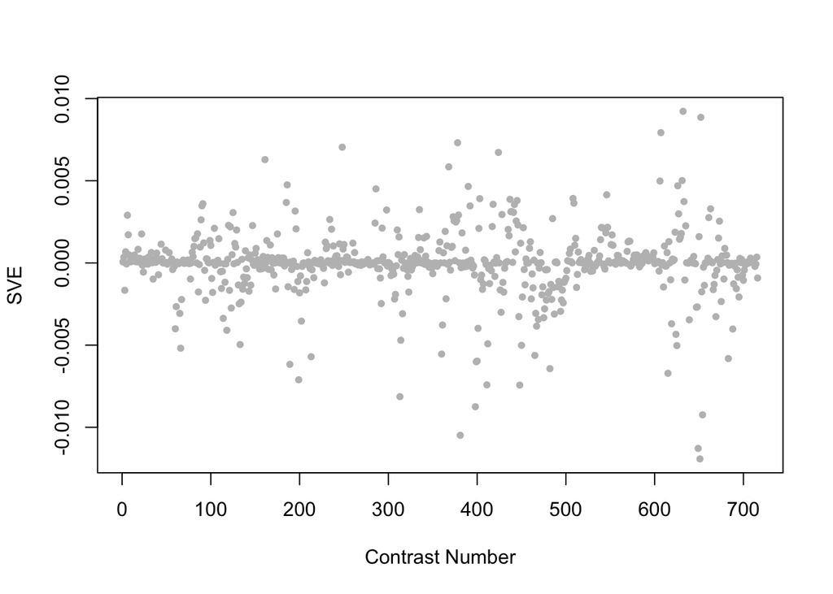

Positive SVE Contrasts:

|  | Contrast.Num | SVE | GEO.GSE | Cond.1 | Cond.2 | Mutation |
| --- | --- | --- | --- | --- | --- | --- |
| GSE19310B.s1t2.vs.s1t1 | 632 | 0.01 | GSE19310 | N2 at 200 for 1 hour, rep1 | N2 at 200 for 15min, rep1 |  |
| GSE16405.s3t1.vs.s2t1 | 652 | 0.01 | GSE16405 | nth-1;xpa-1_1 | nth-1_1 | xpa-1 |
| GSE21784.s1t1.vs.s2t1 | 607 | 0.01 | GSE21784 | L4 larvae, biological rep1 | day 6 adults, biological rep 1 |  |
| GSE35354B.s1t4.vs.s1t1 | 378 | 0.01 | GSE35354 | TA300_rep1 | TA Control_rep1 |  |
| GSE42192.s1t2.vs.s0t2 | 248 | 0.01 | GSE42192 | C.elegans fed with CNCM I-3690 10 days rep1 | C.elegans fed with E.coli OP50 10 days rep1 |  |

Negative SVE Contrasts:

|  | Contrast.Num | SVE | GEO.GSE | Cond.1 | Cond.2 | Mutation |
| --- | --- | --- | --- | --- | --- | --- |
| GSE16405.s4t1.vs.s1t1 | 651 | -0.01 | GSE16405 | xpa-1_1 | N2_1 | xpa-1 |
| GSE16405.s2t1.vs.s1t1 | 649 | -0.01 | GSE16405 | nth-1_1 | N2_1 | nth-1 |
| GSE34471.s0t2.vs.s0t1 | 381 | -0.01 | GSE34471 | 20uM-Con-1 | 4uM-Con-1 |  |
| GSE16405.s4t1.vs.s3t1 | 654 | -0.01 | GSE16405 | xpa-1_1 | nth-1;xpa-1_1 | nth-1 |
| GSE30505.s2t2.vs.s4t2 | 398 | -0.01 | GSE30505 | Day 8 N2 (WT) ash-2 #1 | Day 8 glp-1 ash-2 #1 | glp-1 |

$~$

#### Contrast SVE, Up-Regulated Genes Only:

Calculating SVE for up-regulated and down-regulated genes separately may be more informative in many cases than projecting the up- and down- gene sets together. This is due to the fact that the weight distribution of many modules is highly skewed, indicating that only one of the hemi-modules may be biologically meaningful (i.e., a set of genes are strongly correlated by only a few genes (or none) are strongly anti-correlated to that set.)

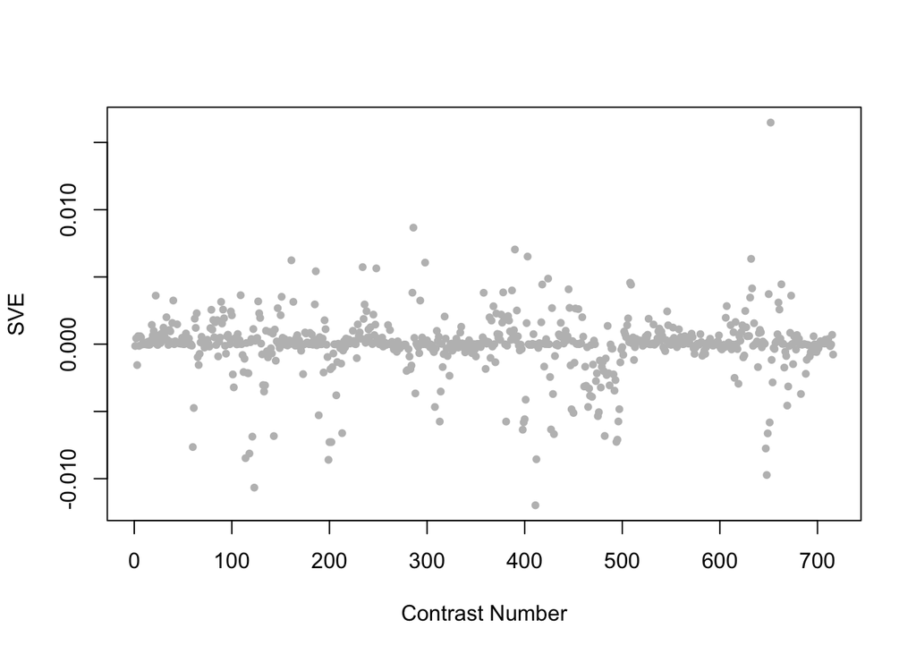

Positive SVE Contrasts:

|  | Contrast.Num | SVE | GEO.GSE | Cond.1 | Cond.2 | Mutation |
| --- | --- | --- | --- | --- | --- | --- |
| GSE16405.s3t1.vs.s2t1 | 652 | 0.02 | GSE16405 | nth-1;xpa-1_1 | nth-1_1 | xpa-1 |
| GSE41366C.s1t1.vs.s0t1 | 286 | 0.01 | GSE41366 | low_DDVP-continuous_expose-2h_harvest-rep1 | control-continuous_expose-0h_harvest-rep2 |  |
| GSE32521.s1t1.vs.s0t1 | 390 | 0.01 | GSE32521 | Au-NP Replicate1 | Control Replicate1 |  |
| GSE30505.s3t1.vs.s4t1 | 403 | 0.01 | GSE30505 | L3 glp-1 E.V. #1 | L3 glp-1 ash-2 #1 | ash-2 |
| GSE19310B.s1t2.vs.s1t1 | 632 | 0.01 | GSE19310 | N2 at 200 for 1 hour, rep1 | N2 at 200 for 15min, rep1 |  |

Negative SVE Contrasts:

|  | Contrast.Num | SVE | GEO.GSE | Cond.1 | Cond.2 | Mutation |
| --- | --- | --- | --- | --- | --- | --- |
| GSE30505.s2t2.vs.s2t1 | 411 | -0.01 | GSE30505 | Day 8 N2 (WT) ash-2 #1 | L3 N2 (WT) ash-2 #1 |  |
| GSE54024.s2t1.vs.s3t1 | 123 | -0.01 | GSE54024 | Wild type young adults treated with 0.1mM paraquat, biological rep 1 | nuo-6(qm200) young adults, biological rep 1 |  |
| GSE16753.s1t1.vs.s0t1 | 648 | -0.01 | GSE16753 | fer-1 (hc24ts) mutant young adult biological rep 1 | Wild-type young adult biological rep 3 | fer-1 |
| GSE43959.s1t2.vs.s4t2 | 199 | -0.01 | GSE43959 | N2 gravid adult on E. coli OP50 rep 1 | N2 gravid adult on 1:1000 Comamonas DA1877 rep 1 |  |
| GSE30505.s1t2.vs.s1t1 | 412 | -0.01 | GSE30505 | Day 8 N2 (WT) E.V. #1 | L3 N2 (WT) E.V. #1 |  |

$~$

#### Contrast SVE, Down-Regulated Genes Only:

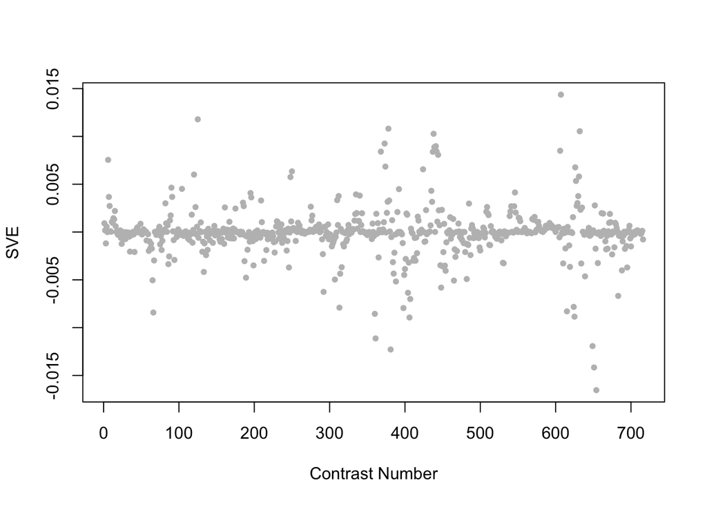

Positive SVE Contrasts:

|  | Contrast.Num | SVE | GEO.GSE | Cond.1 | Cond.2 | Mutation |
| --- | --- | --- | --- | --- | --- | --- |
| GSE21784.s1t1.vs.s2t1 | 607 | 0.01 | GSE21784 | L4 larvae, biological rep1 | day 6 adults, biological rep 1 |  |
| GSE54024.s1t1.vs.s2t1 | 125 | 0.01 | GSE54024 | Wild type young adults, biological rep 1 | Wild type young adults treated with 0.1mM paraquat, biological rep 1 |  |
| GSE35354B.s1t4.vs.s1t1 | 378 | 0.01 | GSE35354 | TA300_rep1 | TA Control_rep1 |  |
| GSE19310B.s1t2.vs.s1t1 | 632 | 0.01 | GSE19310 | N2 at 200 for 1 hour, rep1 | N2 at 200 for 15min, rep1 |  |
| GSE27677B.s1t6.vs.s1t1 | 438 | 0.01 | GSE27677 | N2, Fast 18 h, rep 1 | N2, Fed 0 h, rep 1 |  |

Negative SVE Contrasts:

|  | Contrast.Num | SVE | GEO.GSE | Cond.1 | Cond.2 | Mutation |
| --- | --- | --- | --- | --- | --- | --- |
| GSE16405.s4t1.vs.s3t1 | 654 | -0.02 | GSE16405 | xpa-1_1 | nth-1;xpa-1_1 | nth-1 |
| GSE16405.s4t1.vs.s1t1 | 651 | -0.01 | GSE16405 | xpa-1_1 | N2_1 | xpa-1 |
| GSE34471.s0t2.vs.s0t1 | 381 | -0.01 | GSE34471 | 20uM-Con-1 | 4uM-Con-1 |  |
| GSE16405.s2t1.vs.s1t1 | 649 | -0.01 | GSE16405 | nth-1_1 | N2_1 | nth-1 |
| GSE37432.s2t1.vs.s0t1 | 361 | -0.01 | GSE37432 | piwi n4503 nDf57 rep1 | N2 rep1 | prg-1;prg-2 |

$~$

$~$

#### GO Term Enrichment:

This analysis tests each hemi-module for enrichment of specific GO terms. Only gene-level annotations (e.g., as would be found on the gene’s page in Wormbase) are tested - the hierarchical structure of the GO ontology is not taken into account.

*Note: At least the top two most enriched terms from each GO domain (BP/MF/CC) are shown, even when not statistically significant.*

##### Enriched GO terms: Hemi-module A

| ID | GO.Term | GO Domain | Raw p-value | Adj p-value |
| --- | --- | --- | --- | --- |
| [GO_0035721](http://amigo.geneontology.org/amigo/term/GO:0035721) | intraciliary retrograde transport | BP | 1.49e-03 | 9.96e-01 |
| [GO_0009269](http://amigo.geneontology.org/amigo/term/GO:0009269) | response to desiccation | BP | 6.57e-03 | 9.96e-01 |
| [GO_0001888](http://amigo.geneontology.org/amigo/term/GO:0001888) | glucuronyl-galactosyl-proteoglycan 4-alpha-N-acetylglucosaminyltransferase activity | MF | 6.57e-03 | 9.99e-01 |
| [GO_0015199](http://amigo.geneontology.org/amigo/term/GO:0015199) | amino-acid betaine transmembrane transporter activity | MF | 6.57e-03 | 9.99e-01 |
| [GO_0030991](http://amigo.geneontology.org/amigo/term/GO:0030991) | intraciliary transport particle A | CC | 4.20e-04 | 3.90e-01 |
| [GO_0005780](http://amigo.geneontology.org/amigo/term/GO:0005780) | extrinsic component of intraperoxisomal membrane | CC | 6.57e-03 | 9.98e-01 |

##### Enriched GO terms: Hemi-module B

| ID | GO.Term | GO Domain | Raw p-value | Adj p-value |
| --- | --- | --- | --- | --- |
| [GO_0015837](http://amigo.geneontology.org/amigo/term/GO:0015837) | amine transport | BP | 5.24e-03 | 9.98e-01 |
| [GO_0015874](http://amigo.geneontology.org/amigo/term/GO:0015874) | norepinephrine transport | BP | 5.24e-03 | 9.98e-01 |
| [GO_0016747](http://amigo.geneontology.org/amigo/term/GO:0016747) | transferase activity, transferring acyl groups other than amino-acyl groups | MF | 3.79e-03 | 1.00e+00 |
| [GO_0004057](http://amigo.geneontology.org/amigo/term/GO:0004057) | arginyltransferase activity | MF | 5.24e-03 | 1.00e+00 |
| [GO_0012505](http://amigo.geneontology.org/amigo/term/GO:0012505) | endomembrane system | CC | 4.36e-03 | 9.99e-01 |
| [GO_0030673](http://amigo.geneontology.org/amigo/term/GO:0030673) | axolemma | CC | 2.59e-02 | 9.99e-01 |

$~$

$~$

#### Tissue Enrichment:

This analysis tests each hemi-module for enrichment of genes associated with anatomy terms. Negative enrichment scores indicate fewer hemi-module genes than expected by random chance were associated with the anatomy term in question.

##### Enriched tissues: Hemi-module A

No significant annotations.

##### Enriched tissues: Hemi-module B

No significant annotations.

$~$

$~$

#### HOMER promoter motif enrichment:

This analysis tests each hemi-module for enrichment of 108 known *C. elegans* transcription factor binding site motifs (see [108 CE motifs](https://katiepod.github.io//all.worm.motifs.html)) using the HOMER (Hypergeometric Optimization of Motif EnRichment) software (see [PMID:20513432](https://pubmed.ncbi.nlm.nih.gov/20513432)). HOMER was run using default parameters on sequences 1 kb upstream of the transcription start site.

##### Motif enrichment: Hemi-module A

Total target sequences = 114  
Total background sequences = 40513  
* - possible false positive

Rank

Motif

P-value

log P-pvalue

% of Targets

% of Background

STD(Bg STD)

Best Match/Details

Motif File

1 *

[figure not shown]

1e-10

-2.306e+01

8.77%

0.42%

295.1bp (286.6bp)

fkh-9/MA1440.1/Jaspar(0.566)  
[More Information](https://katiepod.github.io/HomerResults/m115_a_hemi_genes.txt.out.1kb/homerResults/motif1.info.html) | [Similar Motifs Found](https://katiepod.github.io/HomerResults/m115_a_hemi_genes.txt.out.1kb/homerResults/motif1.similar.html)

[motif file (matrix)](https://katiepod.github.io/HomerResults/m115_a_hemi_genes.txt.out.1kb/homerResults/motif1.motif)

2 *

[figure not shown]

1e-9

-2.285e+01

12.28%

1.17%

233.3bp (291.6bp)

lim-7/MA1441.1/Jaspar(0.517)  
[More Information](https://katiepod.github.io/HomerResults/m115_a_hemi_genes.txt.out.1kb/homerResults/motif2.info.html) | [Similar Motifs Found](https://katiepod.github.io/HomerResults/m115_a_hemi_genes.txt.out.1kb/homerResults/motif2.similar.html)

[motif file (matrix)](https://katiepod.github.io/HomerResults/m115_a_hemi_genes.txt.out.1kb/homerResults/motif2.motif)

3 *

[figure not shown]

1e-9

-2.245e+01

15.79%

2.30%

258.9bp (310.6bp)

ceh-38/MA1699.1/Jaspar(0.634)  
[More Information](https://katiepod.github.io/HomerResults/m115_a_hemi_genes.txt.out.1kb/homerResults/motif3.info.html) | [Similar Motifs Found](https://katiepod.github.io/HomerResults/m115_a_hemi_genes.txt.out.1kb/homerResults/motif3.similar.html)

[motif file (matrix)](https://katiepod.github.io/HomerResults/m115_a_hemi_genes.txt.out.1kb/homerResults/motif3.motif)

4 *

[figure not shown]

1e-9

-2.107e+01

9.65%

0.69%

274.4bp (294.7bp)

POL010.1_DCE_S_III/Jaspar(0.528)  
[More Information](https://katiepod.github.io/HomerResults/m115_a_hemi_genes.txt.out.1kb/homerResults/motif4.info.html) | [Similar Motifs Found](https://katiepod.github.io/HomerResults/m115_a_hemi_genes.txt.out.1kb/homerResults/motif4.similar.html)

[motif file (matrix)](https://katiepod.github.io/HomerResults/m115_a_hemi_genes.txt.out.1kb/homerResults/motif4.motif)

5 *

[figure not shown]

1e-9

-2.097e+01

11.40%

1.12%

309.9bp (311.1bp)

blmp-1/MA0537.1/Jaspar(0.646)  
[More Information](https://katiepod.github.io/HomerResults/m115_a_hemi_genes.txt.out.1kb/homerResults/motif5.info.html) | [Similar Motifs Found](https://katiepod.github.io/HomerResults/m115_a_hemi_genes.txt.out.1kb/homerResults/motif5.similar.html)

[motif file (matrix)](https://katiepod.github.io/HomerResults/m115_a_hemi_genes.txt.out.1kb/homerResults/motif5.motif)

6 *

[figure not shown]

1e-8

-2.058e+01

21.93%

5.26%

308.0bp (302.3bp)

fkh-9/MA1440.1/Jaspar(0.602)  
[More Information](https://katiepod.github.io/HomerResults/m115_a_hemi_genes.txt.out.1kb/homerResults/motif6.info.html) | [Similar Motifs Found](https://katiepod.github.io/HomerResults/m115_a_hemi_genes.txt.out.1kb/homerResults/motif6.similar.html)

[motif file (matrix)](https://katiepod.github.io/HomerResults/m115_a_hemi_genes.txt.out.1kb/homerResults/motif6.motif)

7 *

[figure not shown]

1e-8

-2.032e+01

17.54%

3.33%

322.3bp (293.4bp)

PHA-4(Forkhead)/cElegans-Embryos-PHA4-ChIP-Seq(modEncode)/Homer(0.506)  
[More Information](https://katiepod.github.io/HomerResults/m115_a_hemi_genes.txt.out.1kb/homerResults/motif7.info.html) | [Similar Motifs Found](https://katiepod.github.io/HomerResults/m115_a_hemi_genes.txt.out.1kb/homerResults/motif7.similar.html)

[motif file (matrix)](https://katiepod.github.io/HomerResults/m115_a_hemi_genes.txt.out.1kb/homerResults/motif7.motif)

8 *

[figure not shown]

1e-8

-1.989e+01

7.89%

0.42%

327.0bp (294.6bp)

fos-1/MA1448.1/Jaspar(0.567)  
[More Information](https://katiepod.github.io/HomerResults/m115_a_hemi_genes.txt.out.1kb/homerResults/motif8.info.html) | [Similar Motifs Found](https://katiepod.github.io/HomerResults/m115_a_hemi_genes.txt.out.1kb/homerResults/motif8.similar.html)

[motif file (matrix)](https://katiepod.github.io/HomerResults/m115_a_hemi_genes.txt.out.1kb/homerResults/motif8.motif)

9 *

[figure not shown]

1e-8

-1.887e+01

7.02%

0.33%

258.3bp (295.7bp)

MF0005.1_Forkhead_class/Jaspar(0.658)  
[More Information](https://katiepod.github.io/HomerResults/m115_a_hemi_genes.txt.out.1kb/homerResults/motif9.info.html) | [Similar Motifs Found](https://katiepod.github.io/HomerResults/m115_a_hemi_genes.txt.out.1kb/homerResults/motif9.similar.html)

[motif file (matrix)](https://katiepod.github.io/HomerResults/m115_a_hemi_genes.txt.out.1kb/homerResults/motif9.motif)

10 *

[figure not shown]

1e-8

-1.884e+01

4.39%

0.05%

235.1bp (288.8bp)

unc-86/MA0926.1/Jaspar(0.506)  
[More Information](https://katiepod.github.io/HomerResults/m115_a_hemi_genes.txt.out.1kb/homerResults/motif10.info.html) | [Similar Motifs Found](https://katiepod.github.io/HomerResults/m115_a_hemi_genes.txt.out.1kb/homerResults/motif10.similar.html)

[motif file (matrix)](https://katiepod.github.io/HomerResults/m115_a_hemi_genes.txt.out.1kb/homerResults/motif10.motif)

11 *

[figure not shown]

1e-8

-1.861e+01

4.39%

0.05%

301.5bp (451.5bp)

CES-1(Homeobox)/cElegans-L1-CES1-ChIP-Seq(modEncode)/Homer(0.619)  
[More Information](https://katiepod.github.io/HomerResults/m115_a_hemi_genes.txt.out.1kb/homerResults/motif11.info.html) | [Similar Motifs Found](https://katiepod.github.io/HomerResults/m115_a_hemi_genes.txt.out.1kb/homerResults/motif11.similar.html)

[motif file (matrix)](https://katiepod.github.io/HomerResults/m115_a_hemi_genes.txt.out.1kb/homerResults/motif11.motif)

12 *

[figure not shown]

1e-8

-1.848e+01

9.65%

0.90%

274.4bp (322.6bp)

POL003.1_GC-box/Jaspar(0.632)  
[More Information](https://katiepod.github.io/HomerResults/m115_a_hemi_genes.txt.out.1kb/homerResults/motif12.info.html) | [Similar Motifs Found](https://katiepod.github.io/HomerResults/m115_a_hemi_genes.txt.out.1kb/homerResults/motif12.similar.html)

[motif file (matrix)](https://katiepod.github.io/HomerResults/m115_a_hemi_genes.txt.out.1kb/homerResults/motif12.motif)

13 *

[figure not shown]

1e-7

-1.841e+01

7.89%

0.50%

268.3bp (305.7bp)

MF0006.1_bZIP_cEBP-like_subclass/Jaspar(0.615)  
[More Information](https://katiepod.github.io/HomerResults/m115_a_hemi_genes.txt.out.1kb/homerResults/motif13.info.html) | [Similar Motifs Found](https://katiepod.github.io/HomerResults/m115_a_hemi_genes.txt.out.1kb/homerResults/motif13.similar.html)

[motif file (matrix)](https://katiepod.github.io/HomerResults/m115_a_hemi_genes.txt.out.1kb/homerResults/motif13.motif)

14 *

[figure not shown]

1e-7

-1.764e+01

17.54%

3.92%

260.3bp (296.8bp)

MF0004.1_Nuclear_Receptor_class/Jaspar(0.532)  
[More Information](https://katiepod.github.io/HomerResults/m115_a_hemi_genes.txt.out.1kb/homerResults/motif14.info.html) | [Similar Motifs Found](https://katiepod.github.io/HomerResults/m115_a_hemi_genes.txt.out.1kb/homerResults/motif14.similar.html)

[motif file (matrix)](https://katiepod.github.io/HomerResults/m115_a_hemi_genes.txt.out.1kb/homerResults/motif14.motif)

15 *

[figure not shown]

1e-7

-1.762e+01

8.77%

0.75%

220.2bp (305.0bp)

cebp-1/MA1444.1/Jaspar(0.597)  
[More Information](https://katiepod.github.io/HomerResults/m115_a_hemi_genes.txt.out.1kb/homerResults/motif15.info.html) | [Similar Motifs Found](https://katiepod.github.io/HomerResults/m115_a_hemi_genes.txt.out.1kb/homerResults/motif15.similar.html)

[motif file (matrix)](https://katiepod.github.io/HomerResults/m115_a_hemi_genes.txt.out.1kb/homerResults/motif15.motif)

16 *

[figure not shown]

1e-7

-1.761e+01

9.65%

0.98%

259.0bp (288.9bp)

PL0018.1_hlh-25/Jaspar(0.630)  
[More Information](https://katiepod.github.io/HomerResults/m115_a_hemi_genes.txt.out.1kb/homerResults/motif16.info.html) | [Similar Motifs Found](https://katiepod.github.io/HomerResults/m115_a_hemi_genes.txt.out.1kb/homerResults/motif16.similar.html)

[motif file (matrix)](https://katiepod.github.io/HomerResults/m115_a_hemi_genes.txt.out.1kb/homerResults/motif16.motif)

17 *

[figure not shown]

1e-7

-1.668e+01

7.02%

0.44%

251.1bp (313.1bp)

pal-1/MA0924.1/Jaspar(0.655)  
[More Information](https://katiepod.github.io/HomerResults/m115_a_hemi_genes.txt.out.1kb/homerResults/motif17.info.html) | [Similar Motifs Found](https://katiepod.github.io/HomerResults/m115_a_hemi_genes.txt.out.1kb/homerResults/motif17.similar.html)

[motif file (matrix)](https://katiepod.github.io/HomerResults/m115_a_hemi_genes.txt.out.1kb/homerResults/motif17.motif)

18 *

[figure not shown]

1e-7

-1.645e+01

14.91%

3.02%

206.5bp (301.6bp)

elt-3/MA0542.1/Jaspar(0.668)  
[More Information](https://katiepod.github.io/HomerResults/m115_a_hemi_genes.txt.out.1kb/homerResults/motif18.info.html) | [Similar Motifs Found](https://katiepod.github.io/HomerResults/m115_a_hemi_genes.txt.out.1kb/homerResults/motif18.similar.html)

[motif file (matrix)](https://katiepod.github.io/HomerResults/m115_a_hemi_genes.txt.out.1kb/homerResults/motif18.motif)

19 *

[figure not shown]

1e-7

-1.640e+01

4.39%

0.08%

253.8bp (258.7bp)

MF0009.1_TRP(MYB)_class/Jaspar(0.567)  
[More Information](https://katiepod.github.io/HomerResults/m115_a_hemi_genes.txt.out.1kb/homerResults/motif19.info.html) | [Similar Motifs Found](https://katiepod.github.io/HomerResults/m115_a_hemi_genes.txt.out.1kb/homerResults/motif19.similar.html)

[motif file (matrix)](https://katiepod.github.io/HomerResults/m115_a_hemi_genes.txt.out.1kb/homerResults/motif19.motif)

20 *

[figure not shown]

1e-6

-1.539e+01

7.89%

0.73%

306.9bp (291.8bp)

zip-8/MA1704.1/Jaspar(0.609)  
[More Information](https://katiepod.github.io/HomerResults/m115_a_hemi_genes.txt.out.1kb/homerResults/motif20.info.html) | [Similar Motifs Found](https://katiepod.github.io/HomerResults/m115_a_hemi_genes.txt.out.1kb/homerResults/motif20.similar.html)

[motif file (matrix)](https://katiepod.github.io/HomerResults/m115_a_hemi_genes.txt.out.1kb/homerResults/motif20.motif)

21 *

[figure not shown]

1e-6

-1.431e+01

10.53%

1.68%

266.0bp (296.7bp)

lim-7/MA1441.1/Jaspar(0.607)  
[More Information](https://katiepod.github.io/HomerResults/m115_a_hemi_genes.txt.out.1kb/homerResults/motif21.info.html) | [Similar Motifs Found](https://katiepod.github.io/HomerResults/m115_a_hemi_genes.txt.out.1kb/homerResults/motif21.similar.html)

[motif file (matrix)](https://katiepod.github.io/HomerResults/m115_a_hemi_genes.txt.out.1kb/homerResults/motif21.motif)

22 *

[figure not shown]

1e-6

-1.423e+01

5.26%

0.25%

155.3bp (317.5bp)

SD0003.1_at_AC_acceptor/Jaspar(0.531)  
[More Information](https://katiepod.github.io/HomerResults/m115_a_hemi_genes.txt.out.1kb/homerResults/motif22.info.html) | [Similar Motifs Found](https://katiepod.github.io/HomerResults/m115_a_hemi_genes.txt.out.1kb/homerResults/motif22.similar.html)

[motif file (matrix)](https://katiepod.github.io/HomerResults/m115_a_hemi_genes.txt.out.1kb/homerResults/motif22.motif)

23 *

[figure not shown]

1e-6

-1.403e+01

17.54%

4.92%

303.8bp (314.9bp)

SD0003.1_at_AC_acceptor/Jaspar(0.634)  
[More Information](https://katiepod.github.io/HomerResults/m115_a_hemi_genes.txt.out.1kb/homerResults/motif23.info.html) | [Similar Motifs Found](https://katiepod.github.io/HomerResults/m115_a_hemi_genes.txt.out.1kb/homerResults/motif23.similar.html)

[motif file (matrix)](https://katiepod.github.io/HomerResults/m115_a_hemi_genes.txt.out.1kb/homerResults/motif23.motif)

24 *

[figure not shown]

1e-5

-1.264e+01

19.30%

6.40%

268.8bp (313.8bp)

PQM-1(?)/cElegans-L3-ChIP-Seq(modEncode)/Homer(0.905)  
[More Information](https://katiepod.github.io/HomerResults/m115_a_hemi_genes.txt.out.1kb/homerResults/motif24.info.html) | [Similar Motifs Found](https://katiepod.github.io/HomerResults/m115_a_hemi_genes.txt.out.1kb/homerResults/motif24.similar.html)

[motif file (matrix)](https://katiepod.github.io/HomerResults/m115_a_hemi_genes.txt.out.1kb/homerResults/motif24.motif)

25 *

[figure not shown]

1e-4

-1.138e+01

14.91%

4.40%

242.1bp (297.8bp)

eor-1/MA0543.1/Jaspar(0.728)  
[More Information](https://katiepod.github.io/HomerResults/m115_a_hemi_genes.txt.out.1kb/homerResults/motif25.info.html) | [Similar Motifs Found](https://katiepod.github.io/HomerResults/m115_a_hemi_genes.txt.out.1kb/homerResults/motif25.similar.html)

[motif file (matrix)](https://katiepod.github.io/HomerResults/m115_a_hemi_genes.txt.out.1kb/homerResults/motif25.motif)

26 *

[figure not shown]

1e-4

-1.135e+01

7.02%

0.91%

295.9bp (274.6bp)

POL004.1_CCAAT-box/Jaspar(0.560)  
[More Information](https://katiepod.github.io/HomerResults/m115_a_hemi_genes.txt.out.1kb/homerResults/motif26.info.html) | [Similar Motifs Found](https://katiepod.github.io/HomerResults/m115_a_hemi_genes.txt.out.1kb/homerResults/motif26.similar.html)

[motif file (matrix)](https://katiepod.github.io/HomerResults/m115_a_hemi_genes.txt.out.1kb/homerResults/motif26.motif)

27 *

[figure not shown]

1e-4

-1.123e+01

39.47%

21.66%

285.7bp (306.4bp)

daf-16/MA1446.1/Jaspar(0.646)  
[More Information](https://katiepod.github.io/HomerResults/m115_a_hemi_genes.txt.out.1kb/homerResults/motif27.info.html) | [Similar Motifs Found](https://katiepod.github.io/HomerResults/m115_a_hemi_genes.txt.out.1kb/homerResults/motif27.similar.html)

[motif file (matrix)](https://katiepod.github.io/HomerResults/m115_a_hemi_genes.txt.out.1kb/homerResults/motif27.motif)

28 *

[figure not shown]

1e-4

-1.109e+01

24.56%

10.50%

269.6bp (305.2bp)

elt-2/MA1701.1/Jaspar(0.563)  
[More Information](https://katiepod.github.io/HomerResults/m115_a_hemi_genes.txt.out.1kb/homerResults/motif28.info.html) | [Similar Motifs Found](https://katiepod.github.io/HomerResults/m115_a_hemi_genes.txt.out.1kb/homerResults/motif28.similar.html)

[motif file (matrix)](https://katiepod.github.io/HomerResults/m115_a_hemi_genes.txt.out.1kb/homerResults/motif28.motif)

29 *

[figure not shown]

1e-4

-1.019e+01

3.51%

0.15%

200.9bp (279.8bp)

POL013.1_MED-1/Jaspar(0.627)  
[More Information](https://katiepod.github.io/HomerResults/m115_a_hemi_genes.txt.out.1kb/homerResults/motif29.info.html) | [Similar Motifs Found](https://katiepod.github.io/HomerResults/m115_a_hemi_genes.txt.out.1kb/homerResults/motif29.similar.html)

[motif file (matrix)](https://katiepod.github.io/HomerResults/m115_a_hemi_genes.txt.out.1kb/homerResults/motif29.motif)

30 *

[figure not shown]

1e-3

-8.691e+00

14.91%

5.48%

264.0bp (294.5bp)

POL003.1_GC-box/Jaspar(0.784)  
[More Information](https://katiepod.github.io/HomerResults/m115_a_hemi_genes.txt.out.1kb/homerResults/motif30.info.html) | [Similar Motifs Found](https://katiepod.github.io/HomerResults/m115_a_hemi_genes.txt.out.1kb/homerResults/motif30.similar.html)

[motif file (matrix)](https://katiepod.github.io/HomerResults/m115_a_hemi_genes.txt.out.1kb/homerResults/motif30.motif)

##### Motif enrichment: Hemi-module B

Total target sequences = 95  
Total background sequences = 40883  
* - possible false positive

Rank

Motif

P-value

log P-pvalue

% of Targets

% of Background

STD(Bg STD)

Best Match/Details

Motif File

1

[figure not shown]

1e-12

-2.782e+01

13.68%

0.77%

286.6bp (292.4bp)

daf-16/MA1446.1/Jaspar(0.693)  
[More Information](https://katiepod.github.io/HomerResults/m115_b_hemi_genes.txt.out.1kb/homerResults/motif1.info.html) | [Similar Motifs Found](https://katiepod.github.io/HomerResults/m115_b_hemi_genes.txt.out.1kb/homerResults/motif1.similar.html)

[motif file (matrix)](https://katiepod.github.io/HomerResults/m115_b_hemi_genes.txt.out.1kb/homerResults/motif1.motif)

2 *

[figure not shown]

1e-11

-2.697e+01

9.47%

0.22%

318.8bp (290.9bp)

ceh-48/MA0921.1/Jaspar(0.573)  
[More Information](https://katiepod.github.io/HomerResults/m115_b_hemi_genes.txt.out.1kb/homerResults/motif2.info.html) | [Similar Motifs Found](https://katiepod.github.io/HomerResults/m115_b_hemi_genes.txt.out.1kb/homerResults/motif2.similar.html)

[motif file (matrix)](https://katiepod.github.io/HomerResults/m115_b_hemi_genes.txt.out.1kb/homerResults/motif2.motif)

3 *

[figure not shown]

1e-10

-2.396e+01

18.95%

2.55%

257.4bp (315.7bp)

fkh-2/MA0920.1/Jaspar(0.587)  
[More Information](https://katiepod.github.io/HomerResults/m115_b_hemi_genes.txt.out.1kb/homerResults/motif3.info.html) | [Similar Motifs Found](https://katiepod.github.io/HomerResults/m115_b_hemi_genes.txt.out.1kb/homerResults/motif3.similar.html)

[motif file (matrix)](https://katiepod.github.io/HomerResults/m115_b_hemi_genes.txt.out.1kb/homerResults/motif3.motif)

4 *

[figure not shown]

1e-8

-2.059e+01

13.68%

1.41%

251.2bp (313.7bp)

nhr-6/MA1451.1/Jaspar(0.552)  
[More Information](https://katiepod.github.io/HomerResults/m115_b_hemi_genes.txt.out.1kb/homerResults/motif4.info.html) | [Similar Motifs Found](https://katiepod.github.io/HomerResults/m115_b_hemi_genes.txt.out.1kb/homerResults/motif4.similar.html)

[motif file (matrix)](https://katiepod.github.io/HomerResults/m115_b_hemi_genes.txt.out.1kb/homerResults/motif4.motif)

5 *

[figure not shown]

1e-8

-2.051e+01

7.37%

0.19%

341.9bp (331.7bp)

POL012.1_TATA-Box/Jaspar(0.538)  
[More Information](https://katiepod.github.io/HomerResults/m115_b_hemi_genes.txt.out.1kb/homerResults/motif5.info.html) | [Similar Motifs Found](https://katiepod.github.io/HomerResults/m115_b_hemi_genes.txt.out.1kb/homerResults/motif5.similar.html)

[motif file (matrix)](https://katiepod.github.io/HomerResults/m115_b_hemi_genes.txt.out.1kb/homerResults/motif5.motif)

6 *

[figure not shown]

1e-8

-2.005e+01

11.58%

0.93%

281.2bp (287.5bp)

lin-14/MA0261.1/Jaspar(0.591)  
[More Information](https://katiepod.github.io/HomerResults/m115_b_hemi_genes.txt.out.1kb/homerResults/motif6.info.html) | [Similar Motifs Found](https://katiepod.github.io/HomerResults/m115_b_hemi_genes.txt.out.1kb/homerResults/motif6.similar.html)

[motif file (matrix)](https://katiepod.github.io/HomerResults/m115_b_hemi_genes.txt.out.1kb/homerResults/motif6.motif)

7 *

[figure not shown]

1e-8

-1.924e+01

6.32%

0.13%

338.3bp (285.7bp)

elt-3/MA0542.1/Jaspar(0.630)  
[More Information](https://katiepod.github.io/HomerResults/m115_b_hemi_genes.txt.out.1kb/homerResults/motif7.info.html) | [Similar Motifs Found](https://katiepod.github.io/HomerResults/m115_b_hemi_genes.txt.out.1kb/homerResults/motif7.similar.html)

[motif file (matrix)](https://katiepod.github.io/HomerResults/m115_b_hemi_genes.txt.out.1kb/homerResults/motif7.motif)

8 *

[figure not shown]

1e-8

-1.910e+01

8.42%

0.38%

241.0bp (323.1bp)

POL012.1_TATA-Box/Jaspar(0.496)  
[More Information](https://katiepod.github.io/HomerResults/m115_b_hemi_genes.txt.out.1kb/homerResults/motif8.info.html) | [Similar Motifs Found](https://katiepod.github.io/HomerResults/m115_b_hemi_genes.txt.out.1kb/homerResults/motif8.similar.html)

[motif file (matrix)](https://katiepod.github.io/HomerResults/m115_b_hemi_genes.txt.out.1kb/homerResults/motif8.motif)

9 *

[figure not shown]

1e-8

-1.882e+01

7.37%

0.25%

284.0bp (289.1bp)

lim-7/MA1441.1/Jaspar(0.632)  
[More Information](https://katiepod.github.io/HomerResults/m115_b_hemi_genes.txt.out.1kb/homerResults/motif9.info.html) | [Similar Motifs Found](https://katiepod.github.io/HomerResults/m115_b_hemi_genes.txt.out.1kb/homerResults/motif9.similar.html)

[motif file (matrix)](https://katiepod.github.io/HomerResults/m115_b_hemi_genes.txt.out.1kb/homerResults/motif9.motif)

10 *

[figure not shown]

1e-7

-1.834e+01

6.32%

0.15%

268.6bp (324.0bp)

ceh-22/MA0264.1/Jaspar(0.574)  
[More Information](https://katiepod.github.io/HomerResults/m115_b_hemi_genes.txt.out.1kb/homerResults/motif10.info.html) | [Similar Motifs Found](https://katiepod.github.io/HomerResults/m115_b_hemi_genes.txt.out.1kb/homerResults/motif10.similar.html)

[motif file (matrix)](https://katiepod.github.io/HomerResults/m115_b_hemi_genes.txt.out.1kb/homerResults/motif10.motif)

11 *

[figure not shown]

1e-7

-1.724e+01

16.84%

3.04%

303.1bp (300.2bp)

SD0003.1_at_AC_acceptor/Jaspar(0.560)  
[More Information](https://katiepod.github.io/HomerResults/m115_b_hemi_genes.txt.out.1kb/homerResults/motif11.info.html) | [Similar Motifs Found](https://katiepod.github.io/HomerResults/m115_b_hemi_genes.txt.out.1kb/homerResults/motif11.similar.html)

[motif file (matrix)](https://katiepod.github.io/HomerResults/m115_b_hemi_genes.txt.out.1kb/homerResults/motif11.motif)

12 *

[figure not shown]

1e-7

-1.704e+01

12.63%

1.57%

225.4bp (302.0bp)

lin-14/MA0261.1/Jaspar(0.569)  
[More Information](https://katiepod.github.io/HomerResults/m115_b_hemi_genes.txt.out.1kb/homerResults/motif12.info.html) | [Similar Motifs Found](https://katiepod.github.io/HomerResults/m115_b_hemi_genes.txt.out.1kb/homerResults/motif12.similar.html)

[motif file (matrix)](https://katiepod.github.io/HomerResults/m115_b_hemi_genes.txt.out.1kb/homerResults/motif12.motif)

13 *

[figure not shown]

1e-7

-1.702e+01

7.37%

0.33%

253.4bp (337.7bp)

sma-4/MA0925.1/Jaspar(0.636)  
[More Information](https://katiepod.github.io/HomerResults/m115_b_hemi_genes.txt.out.1kb/homerResults/motif13.info.html) | [Similar Motifs Found](https://katiepod.github.io/HomerResults/m115_b_hemi_genes.txt.out.1kb/homerResults/motif13.similar.html)

[motif file (matrix)](https://katiepod.github.io/HomerResults/m115_b_hemi_genes.txt.out.1kb/homerResults/motif13.motif)

14 *

[figure not shown]

1e-7

-1.652e+01

9.47%

0.77%

213.2bp (302.8bp)

lin-54/MA1450.1/Jaspar(0.694)  
[More Information](https://katiepod.github.io/HomerResults/m115_b_hemi_genes.txt.out.1kb/homerResults/motif14.info.html) | [Similar Motifs Found](https://katiepod.github.io/HomerResults/m115_b_hemi_genes.txt.out.1kb/homerResults/motif14.similar.html)

[motif file (matrix)](https://katiepod.github.io/HomerResults/m115_b_hemi_genes.txt.out.1kb/homerResults/motif14.motif)

15 *

[figure not shown]

1e-7

-1.642e+01

11.58%

1.34%

268.6bp (300.7bp)

lin-54/MA1450.1/Jaspar(0.529)  
[More Information](https://katiepod.github.io/HomerResults/m115_b_hemi_genes.txt.out.1kb/homerResults/motif15.info.html) | [Similar Motifs Found](https://katiepod.github.io/HomerResults/m115_b_hemi_genes.txt.out.1kb/homerResults/motif15.similar.html)

[motif file (matrix)](https://katiepod.github.io/HomerResults/m115_b_hemi_genes.txt.out.1kb/homerResults/motif15.motif)

16 *

[figure not shown]

1e-6

-1.536e+01

17.89%

3.97%

230.5bp (322.0bp)

dpy-27/MA0540.1/Jaspar(0.545)  
[More Information](https://katiepod.github.io/HomerResults/m115_b_hemi_genes.txt.out.1kb/homerResults/motif16.info.html) | [Similar Motifs Found](https://katiepod.github.io/HomerResults/m115_b_hemi_genes.txt.out.1kb/homerResults/motif16.similar.html)

[motif file (matrix)](https://katiepod.github.io/HomerResults/m115_b_hemi_genes.txt.out.1kb/homerResults/motif16.motif)

17 *

[figure not shown]

1e-6

-1.524e+01

8.42%

0.64%

216.1bp (316.0bp)

MF0006.1_bZIP_cEBP-like_subclass/Jaspar(0.635)  
[More Information](https://katiepod.github.io/HomerResults/m115_b_hemi_genes.txt.out.1kb/homerResults/motif17.info.html) | [Similar Motifs Found](https://katiepod.github.io/HomerResults/m115_b_hemi_genes.txt.out.1kb/homerResults/motif17.similar.html)

[motif file (matrix)](https://katiepod.github.io/HomerResults/m115_b_hemi_genes.txt.out.1kb/homerResults/motif17.motif)

18 *

[figure not shown]

1e-6

-1.488e+01

9.47%

0.94%

281.7bp (307.0bp)

SD0002.1_at_AC_acceptor/Jaspar(0.608)  
[More Information](https://katiepod.github.io/HomerResults/m115_b_hemi_genes.txt.out.1kb/homerResults/motif18.info.html) | [Similar Motifs Found](https://katiepod.github.io/HomerResults/m115_b_hemi_genes.txt.out.1kb/homerResults/motif18.similar.html)

[motif file (matrix)](https://katiepod.github.io/HomerResults/m115_b_hemi_genes.txt.out.1kb/homerResults/motif18.motif)

19 *

[figure not shown]

1e-6

-1.470e+01

6.32%

0.28%

200.7bp (304.3bp)

lin-14/MA0261.1/Jaspar(0.553)  
[More Information](https://katiepod.github.io/HomerResults/m115_b_hemi_genes.txt.out.1kb/homerResults/motif19.info.html) | [Similar Motifs Found](https://katiepod.github.io/HomerResults/m115_b_hemi_genes.txt.out.1kb/homerResults/motif19.similar.html)

[motif file (matrix)](https://katiepod.github.io/HomerResults/m115_b_hemi_genes.txt.out.1kb/homerResults/motif19.motif)

20 *

[figure not shown]

1e-6

-1.469e+01

18.95%

4.68%

277.8bp (306.1bp)

PL0012.1_hlh-2::hlh-8/Jaspar(0.604)  
[More Information](https://katiepod.github.io/HomerResults/m115_b_hemi_genes.txt.out.1kb/homerResults/motif20.info.html) | [Similar Motifs Found](https://katiepod.github.io/HomerResults/m115_b_hemi_genes.txt.out.1kb/homerResults/motif20.similar.html)

[motif file (matrix)](https://katiepod.github.io/HomerResults/m115_b_hemi_genes.txt.out.1kb/homerResults/motif20.motif)

21 *

[figure not shown]

1e-5

-1.380e+01

38.95%

17.78%

295.3bp (315.4bp)

POL006.1_BREu/Jaspar(0.641)  
[More Information](https://katiepod.github.io/HomerResults/m115_b_hemi_genes.txt.out.1kb/homerResults/motif21.info.html) | [Similar Motifs Found](https://katiepod.github.io/HomerResults/m115_b_hemi_genes.txt.out.1kb/homerResults/motif21.similar.html)

[motif file (matrix)](https://katiepod.github.io/HomerResults/m115_b_hemi_genes.txt.out.1kb/homerResults/motif21.motif)

22 *

[figure not shown]

1e-5

-1.353e+01

37.89%

17.19%

298.3bp (305.2bp)

ces-2/MA0922.1/Jaspar(0.490)  
[More Information](https://katiepod.github.io/HomerResults/m115_b_hemi_genes.txt.out.1kb/homerResults/motif22.info.html) | [Similar Motifs Found](https://katiepod.github.io/HomerResults/m115_b_hemi_genes.txt.out.1kb/homerResults/motif22.similar.html)

[motif file (matrix)](https://katiepod.github.io/HomerResults/m115_b_hemi_genes.txt.out.1kb/homerResults/motif22.motif)

23 *

[figure not shown]

1e-5

-1.307e+01

8.42%

0.87%

306.3bp (312.4bp)

elt-3/MA0542.1/Jaspar(0.585)  
[More Information](https://katiepod.github.io/HomerResults/m115_b_hemi_genes.txt.out.1kb/homerResults/motif23.info.html) | [Similar Motifs Found](https://katiepod.github.io/HomerResults/m115_b_hemi_genes.txt.out.1kb/homerResults/motif23.similar.html)

[motif file (matrix)](https://katiepod.github.io/HomerResults/m115_b_hemi_genes.txt.out.1kb/homerResults/motif23.motif)

24 *

[figure not shown]

1e-4

-9.542e+00

9.47%

1.84%

240.7bp (313.2bp)

PL0007.1_mxl-3/Jaspar(0.605)  
[More Information](https://katiepod.github.io/HomerResults/m115_b_hemi_genes.txt.out.1kb/homerResults/motif24.info.html) | [Similar Motifs Found](https://katiepod.github.io/HomerResults/m115_b_hemi_genes.txt.out.1kb/homerResults/motif24.similar.html)

[motif file (matrix)](https://katiepod.github.io/HomerResults/m115_b_hemi_genes.txt.out.1kb/homerResults/motif24.motif)

25 *

[figure not shown]

1e-4

-9.249e+00

9.47%

1.92%

288.3bp (314.4bp)

POL004.1_CCAAT-box/Jaspar(0.599)  
[More Information](https://katiepod.github.io/HomerResults/m115_b_hemi_genes.txt.out.1kb/homerResults/motif25.info.html) | [Similar Motifs Found](https://katiepod.github.io/HomerResults/m115_b_hemi_genes.txt.out.1kb/homerResults/motif25.similar.html)

[motif file (matrix)](https://katiepod.github.io/HomerResults/m115_b_hemi_genes.txt.out.1kb/homerResults/motif25.motif)

26 *

[figure not shown]

1e-3

-9.105e+00

2.11%

0.01%

128.1bp (167.7bp)

ceh-22/MA0264.1/Jaspar(0.529)  
[More Information](https://katiepod.github.io/HomerResults/m115_b_hemi_genes.txt.out.1kb/homerResults/motif26.info.html) | [Similar Motifs Found](https://katiepod.github.io/HomerResults/m115_b_hemi_genes.txt.out.1kb/homerResults/motif26.similar.html)

[motif file (matrix)](https://katiepod.github.io/HomerResults/m115_b_hemi_genes.txt.out.1kb/homerResults/motif26.motif)

$~$

$~$

#### Promoter Word Enrichment:

This analysis tests each hemi-module for enrichment of specific promoter words. The list of promoter words tested was generated by running the MobyDick algorithm (see [PMID:10944202](https://pubmed.ncbi.nlm.nih.gov/10944202)) on the full set of *C. elegans* 2 Kbp promoters.

##### Enriched promoter words: Hemi-module A

No significant words.

##### Enriched promoter words: Hemi-module B

No significant words.

$~$

$~$

#### Promoter Word Depletion:

This analysis tests each hemi-module for depletion (under-enrichment) of specific promoter words. The list of promoter words tested was generated by running the MobyDick algorithm (see [PMID:10944202](https://pubmed.ncbi.nlm.nih.gov/10944202)) on the full set of *C. elegans* 2 Kbp promoters.

##### Depleted promoter words: Hemi-module A

No significant words.

##### Depleted promoter words: Hemi-module B

No significant words.

$~$

$~$

#### 3’-UTR Word Enrichment:

This analysis tests each hemi-module for enrichment of specific 3’-UTR words. The list of words tested was generated by running the MobyDick algorithm (see [PMID:10944202](https://pubmed.ncbi.nlm.nih.gov/10944202)) on the full set of *C. elegans* 3’-UTR sequences.

##### 3’-UTR words: Hemi-module A

No significant words.

##### 3’-UTR words: Hemi-module B

No significant words.

$~$

$~$

#### Hemi-module A genes

| affy_c_elegans | ensembl_gene_id | external_gene_name | module_weight | chromosome_name | strand | start_position | end_position |
| --- | --- | --- | --- | --- | --- | --- | --- |
| 177054_at | WBGene00005735 | srv-24 | 6.77 | IV | -1 | 6288364 | 6290841 |
| 183361_at | WBGene00010467 | K01D12.8 | 6.43 | V | 1 | 12402655 | 12403234 |
| 181229_at | WBGene00017743 | F23F1.2 | 6.22 | II | 1 | 34204 | 35262 |
| 180368_at | WBGene00011712 | T11F9.10 | 6.09 | V | 1 | 11487152 | 11488275 |
| 194027_s_at | WBGene00013201 | dus-2 | 5.32 | I | -1 | 14708195 | 14710961 |
| 182856_at | WBGene00001736 | grl-27 | 5.09 | V | -1 | 3575055 | 3575874 |
| 183841_at | WBGene00016847 | C50F7.9 | 5.09 | IV | -1 | 7730669 | 7732060 |
| 184399_at | WBGene00077684 | Y26D4A.21 | 4.91 | I | 1 | 13101357 | 13101901 |
| 179137_at | WBGene00008816 | F14F8.8 | 4.88 | V | -1 | 16671622 | 16672186 |
| 179154_at | WBGene00012127 | T28D6.7 | 4.78 | III | -1 | 11344255 | 11346789 |
| 185887_at | WBGene00022315 | Y81B9A.1 | 4.54 | X | 1 | 9192444 | 9194382 |
| 193328_at | WBGene00013972 | scl-20 | 4.46 | V | -1 | 18732802 | 18734466 |
| 178680_at | WBGene00010859 | M04C9.4 | 4.36 | I | -1 | 9355072 | 9357079 |
| 176183_at | WBGene00022096 | Y69A2AR.25 | 4.33 | IV | -1 | 2565820 | 2568367 |
| 192496_at | WBGene00000989 | dhs-26 | 4.30 | X | -1 | 3360722 | 3362493 |
| 183580_at | WBGene00012612 | Y38H6A.1 | 4.30 | V | 1 | 20325728 | 20328056 |
| 185941_at | WBGene00002889 | let-765 | 4.20 | III | -1 | 6592567 | 6601171 |
| 191724_at | WBGene00012929 | rsks-1 | 4.17 | III | 1 | 11245120 | 11252281 |
| 178467_at | WBGene00009467 | F36D1.8 | 4.16 | I | -1 | 11256550 | 11259225 |
| 193659_at | WBGene00009824 | gpdh-1 | 4.05 | I | 1 | 14075836 | 14078211 |
| 178133_at | WBGene00008472 | E03H4.4 | 4.04 | I | 1 | 12407564 | 12411435 |
| 180894_at | WBGene00018683 | F52D1.2 | 4.02 | X | -1 | 446356 | 450212 |
| 192372_at | WBGene00011926 | sptf-2 | 4.01 | II | 1 | 8625728 | 8627620 |
| 190002_at | WBGene00016340 | gba-2 | 3.99 | II | -1 | 2182503 | 2186434 |
| 172248_x_at | WBGene00011870 | T20G5.8 | 3.96 | III | 1 | 10199337 | 10199859 |
| 183206_at | WBGene00017197 | F07C3.9 | 3.95 | V | -1 | 9254219 | 9254632 |
| 178421_at | WBGene00008753 | F13E9.4 | 3.94 | IV | -1 | 10895225 | 10896612 |
| 181459_at | WBGene00009914 | F49H6.13 | 3.92 | V | -1 | 17008673 | 17009388 |
| 176686_at | WBGene00017020 | D1014.7 | 3.90 | V | 1 | 8118264 | 8120351 |
| 176851_at | WBGene00021491 | comt-4 | 3.89 | V | -1 | 2049223 | 2050172 |
| 185399_at | WBGene00013559 | Y75B8A.28 | 3.84 | III | 1 | 12319108 | 12323771 |
| 187762_at | WBGene00015488 | C05D11.13 | 3.82 | III | -1 | 6443044 | 6444079 |
| 183149_at | WBGene00044617 | bus-1 | 3.79 | V | -1 | 9022361 | 9024806 |
| 190236_s_at | WBGene00003670 | nhr-80 | 3.78 | III | -1 | 12170 | 14869 |
| 180483_at | WBGene00020943 | W02D7.8 | 3.78 | V | -1 | 8305120 | 8306460 |
| 181712_at | WBGene00007309 | C04G2.10 | 3.76 | IV | 1 | 10115389 | 10118084 |
| 180329_at | WBGene00002138 | inx-16 | 3.74 | I | 1 | 4162035 | 4165015 |
| 182597_at | WBGene00020315 | T07E3.4 | 3.70 | III | 1 | 6898016 | 6900605 |
| 193684_at | WBGene00009247 | bath-45 | 3.68 | II | 1 | 13123038 | 13124789 |
| 189747_at | WBGene00008799 | F14E5.1 | 3.67 | II | 1 | 8417618 | 8419758 |
| 178917_at | WBGene00007728 | C25F9.9 | 3.66 | V | 1 | 19416633 | 19418004 |
| 180561_at | WBGene00021019 | W04B5.2 | 3.61 | III | 1 | 2424355 | 2427738 |
| 179378_at | WBGene00008091 | C44F1.1 | 3.61 | III | -1 | 3760378 | 3765556 |
| 182953_at | WBGene00010429 | H38K22.4 | 3.61 | III | -1 | 4322969 | 4323466 |
| 189314_at | WBGene00016686 | cyp-33C1 | 3.60 | V | 1 | 2179586 | 2181759 |
| 180421_at | WBGene00013060 | Y51A2A.4 | 3.59 | V | 1 | 18290942 | 18291348 |
| 187547_at | WBGene00016002 | C18H9.3 | 3.56 | II | 1 | 6684236 | 6692280 |
| 186541_at | WBGene00009649 | F43C1.5 | 3.54 | III | 1 | 4229141 | 4230427 |
| 189285_at | WBGene00019321 | K02E10.7 | 3.53 | X | -1 | 2501003 | 2508549 |

#### Hemi-module B genes

| affy_c_elegans | ensembl_gene_id | external_gene_name | module_weight | chromosome_name | strand | start_position | end_position |
| --- | --- | --- | --- | --- | --- | --- | --- |
| 189058_at | WBGene00017806 | F26A1.8 | -7.15 | III | -1 | 4820670 | 4822226 |
| 182279_at | WBGene00012947 | Y47H9C.1 | -5.62 | I | -1 | 11830985 | 11833166 |
| 184694_at | WBGene00003099 | lys-10 | -5.11 | IV | 1 | 8332826 | 8333559 |
| 179728_at | WBGene00015600 | fbxa-165 | -4.84 | II | -1 | 1614793 | 1616463 |
| 183218_at | WBGene00020792 | T25B6.6 | -4.83 | X | -1 | 9021922 | 9022833 |
| 190954_at | WBGene00010791 | sodh-2 | -4.75 | V | -1 | 11889719 | 11891194 |
| 190822_s_at | WBGene00011076 | scav-5 | -4.73 | X | 1 | 9858339 | 9861735 |
| 181700_at | WBGene00020791 | T25B6.5 | -4.59 | X | -1 | 9020588 | 9021755 |
| 186692_s_at | WBGene00018061 | arrd-19 | -4.46 | V | -1 | 3313286 | 3315516 |
| 185360_at | WBGene00018813 | F54D11.3 | -4.43 | V | -1 | 4635400 | 4637145 |
| 188799_at | WBGene00005616 | srj-29 | -4.36 | V | 1 | 16075659 | 16077308 |
| 178147_at | WBGene00010162 | F56H6.1 | -4.35 | I | 1 | 12281221 | 12282615 |
| 191605_at | WBGene00001792 | gst-44 | -4.15 | V | 1 | 16390891 | 16392406 |
| 189137_at | WBGene00007744 | C26D10.3 | -4.13 | II | 1 | 8325386 | 8329658 |
| 183399_at | WBGene00012676 | pro-3 | -4.11 | V | -1 | 19101961 | 19118412 |
| 185803_at | WBGene00016180 | C28C12.4 | -4.05 | IV | 1 | 8487497 | 8488481 |
| 184717_at | WBGene00016789 | djr-1.2 | -4.00 | V | -1 | 4054191 | 4055109 |
| 187005_at | WBGene00008050 | chst-1 | -3.98 | II | -1 | 8105614 | 8106967 |
| 191222_at | WBGene00005138 | srd-61 | -3.97 | V | 1 | 2502764 | 2504914 |
| 191222_at | WBGene00044099 | srd-75 | -3.97 | V | 1 | 2394485 | 2396635 |
| 176335_at | WBGene00017877 | F28A10.9 | -3.96 | II | -1 | 833607 | 835270 |
| 187166_at | WBGene00013261 | sinh-1 | -3.94 | II | 1 | 12228305 | 12237051 |
| 182845_s_at | WBGene00007062 | ebp-3 | -3.91 | V | 1 | 18055969 | 18060708 |
| 182845_s_at | WBGene00013344 | ebp-1 | -3.91 | V | 1 | 18043571 | 18052323 |
| 176187_at | WBGene00022085 | Y69A2AR.14 | -3.89 | IV | 1 | 2551872 | 2557106 |
| 180381_at | WBGene00022601 | ZC404.1 | -3.88 | V | 1 | 6794239 | 6795130 |
| 176776_at | WBGene00022103 | cdh-12 | -3.85 | III | 1 | 1152044 | 1181137 |
| 177353_s_at | WBGene00010953 | clec-190 | -3.83 | IV | -1 | 15124931 | 15126122 |
| 189059_s_at | WBGene00017804 | F26A1.6 | -3.80 | III | -1 | 4816040 | 4817078 |
| 189059_s_at | WBGene00017806 | F26A1.8 | -3.80 | III | -1 | 4820670 | 4822226 |
| 189927_at | WBGene00017124 | E04F6.4 | -3.79 | II | 1 | 7189420 | 7192507 |
| 180713_at | WBGene00019558 | srbc-12 | -3.78 | V | 1 | 849499 | 851332 |
| 176786_at | WBGene00017471 | F14H12.3 | -3.78 | X | 1 | 4344215 | 4345644 |
| 173042_s_at | WBGene00001690 | grd-1 | -3.73 | X | 1 | 11109440 | 11115887 |
| 191881_at | WBGene00009427 | fbxa-181 | -3.73 | V | 1 | 13725905 | 13727014 |
| 183989_at | WBGene00017226 | fbxa-53 | -3.72 | X | -1 | 1716442 | 1718568 |
| 186036_at | WBGene00003731 | nhx-3 | -3.68 | V | -1 | 7540890 | 7544838 |
| 180785_at | WBGene00008535 | F02H6.2 | -3.68 | IV | 1 | 14196440 | 14198824 |
| 180785_at | WBGene00168616 | 21ur-14324 | -3.68 | IV | 1 | 14196315 | 14196335 |
| 187831_at | WBGene00016162 | crh-2 | -3.65 | II | -1 | 5179034 | 5187569 |
| 193558_at | WBGene00017811 | F26A1.13 | -3.61 | III | -1 | 4847009 | 4849907 |
| 176787_s_at | WBGene00017471 | F14H12.3 | -3.61 | X | 1 | 4344215 | 4345644 |
| 182955_at | WBGene00016230 | C29G2.2 | -3.60 | V | 1 | 2590393 | 2591758 |
| 191042_at | WBGene00018189 | nhr-181 | -3.58 | V | 1 | 4095040 | 4100541 |
| 177434_at | WBGene00009411 | F35E2.3 | -3.57 | I | -1 | 11733940 | 11735964 |
| 177712_at | WBGene00005271 | srh-48 | -3.57 | II | 1 | 9380822 | 9384995 |
| 178079_at | WBGene00007521 | C11E4.7 | -3.55 | X | 1 | 9617219 | 9619122 |